# R Notebook

# Airline Fares

```r
library(dplyr)
library(readr)
library(GGally)
library(car)
library(ggfortify)
library(forcats)
```

## Read the data

```r
airfares <- read_csv('https://raw.githubusercontent.com/rosagradilla19/Airfares/master/Airfares.csv')
head(airfares)
```

| S_CODE | S_CITY | E_CODE | E_CITY | COUPON | NEW | VACATION | SW | HI | S_INCOME | E_INCOME | S_POP | E_POP | SLOT | GATE | DISTANCE | PAX | FARE |
| --- | --- | --- | --- | --- | --- | --- | --- | --- | --- | --- | --- | --- | --- | --- | --- | --- | --- |
| * | Dallas/Fort Worth TX | * | Amarillo TX | 1.00 | 3 | No | Yes | 5291.99 | 28637 | 21112 | 3036732 | 205711 | Free | Free | 312 | 7864 | 64.11 |
| * | Atlanta GA | * | Baltimore/Wash Intl MD | 1.06 | 3 | No | No | 5419.16 | 26993 | 29838 | 3532657 | 7145897 | Free | Free | 576 | 8820 | 174.47 |
| * | Boston MA | * | Baltimore/Wash Intl MD | 1.06 | 3 | No | No | 9185.28 | 30124 | 29838 | 5787293 | 7145897 | Free | Free | 364 | 6452 | 207.76 |
| ORD | Chicago IL | * | Baltimore/Wash Intl MD | 1.06 | 3 | No | Yes | 2657.35 | 29260 | 29838 | 7830332 | 7145897 | Controlled | Free | 612 | 25144 | 85.47 |
| MDW | Chicago IL | * | Baltimore/Wash Intl MD | 1.06 | 3 | No | Yes | 2657.35 | 29260 | 29838 | 7830332 | 7145897 | Free | Free | 612 | 25144 | 85.47 |
| * | Cleveland OH | * | Baltimore/Wash Intl MD | 1.01 | 3 | No | Yes | 3408.11 | 26046 | 29838 | 2230955 | 7145897 | Free | Free | 309 | 13386 | 56.76 |

## Data Exploration

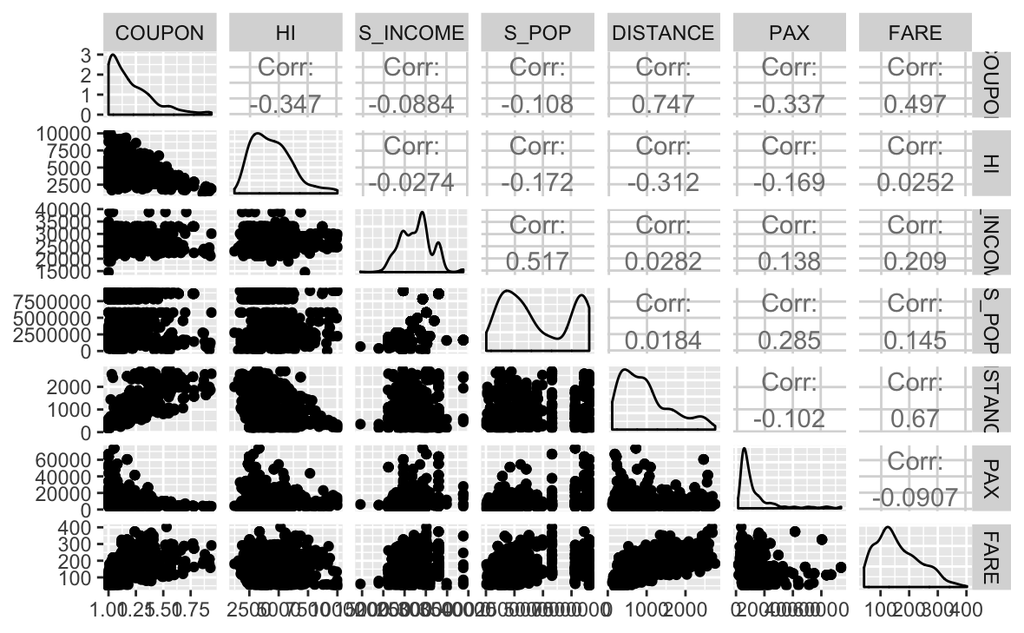

```r
airfares.num <- airfares %>% select(COUPON, NEW, HI, S_INCOME, E_INCOME, S_POP, E_POP, DISTANCE, PAX, FARE)
airfares.cat <- airfares %>% select(S_CODE,S_CITY,E_CODE,E_CITY,VACATION,SW,SLOT,GATE,)
p <- ggpairs(airfares.num,
             columns= c(1,3,4,6,8,9,10),
             progress = FALSE
            )
p
```

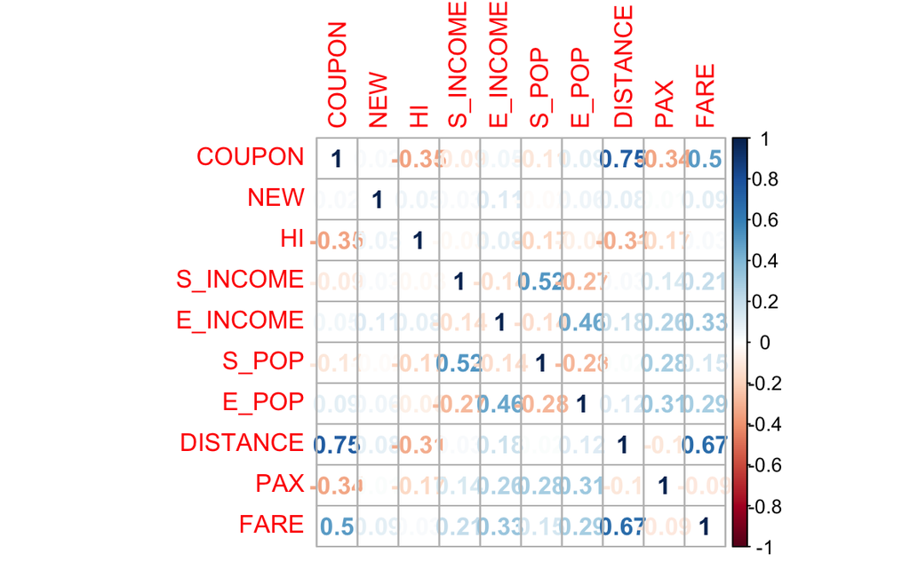

```r
library(corrplot)
cordata <- cor(airfares.num)
corrplot(cordata, method='number')
```

# Multiple Linear Regression

What variables play a significant role in determining a flight’s fare. Response variable is flight fare.

$fare_i=\beta_0+\beta_1coupon_i+\beta_2new_i+\beta_3D_{vacation,i}+\beta_4HI_i+\beta_5s.income_i+\beta_6e.income_i+\beta_7s.pop_i+\beta_8e.pop_i+\beta_9distance_i+\beta_{10}pax_i+\varepsilon_i, \varepsilon_i\sim_{i.i.d}(0,\sigma^2)$

```r
# fitting model to all predictors
mlr <- lm(FARE ~ COUPON + NEW + VACATION + HI + S_INCOME + E_INCOME + S_POP + E_POP + DISTANCE + PAX, data=airfares)
summary(mlr)
```

```
Call:
lm(formula = FARE ~ COUPON + NEW + VACATION + HI + S_INCOME +
    E_INCOME + S_POP + E_POP + DISTANCE + PAX, data = airfares)

Residuals:
    Min      1Q  Median      3Q     Max
-129.17  -26.84    1.20   26.54  123.65

Coefficients:
              Estimate Std. Error t value Pr(>|t|)
(Intercept) -1.928e+02  2.596e+01  -7.425 3.69e-13 ***
COUPON       2.618e+01  1.384e+01   1.892   0.0589 .
NEW         -1.433e+00  2.148e+00  -0.667   0.5049
VACATIONYes -2.818e+01  4.095e+00  -6.881 1.45e-11 ***
HI           1.031e-02  1.106e-03   9.328  < 2e-16 ***
S_INCOME     3.994e-03  5.456e-04   7.322 7.55e-13 ***
E_INCOME     2.528e-03  4.163e-04   6.074 2.17e-09 ***
S_POP        5.178e-06  7.107e-07   7.286 9.61e-13 ***
E_POP        8.088e-06  7.911e-07  10.224  < 2e-16 ***
DISTANCE     7.276e-02  4.010e-03  18.144  < 2e-16 ***
PAX         -1.053e-03  1.667e-04  -6.317 5.06e-10 ***
---
Signif. codes:  0 ‘***’ 0.001 ‘**’ 0.01 ‘*’ 0.05 ‘.’ 0.1 ‘ ’ 1

Residual standard error: 40.68 on 627 degrees of freedom
Multiple R-squared:  0.7181,    Adjusted R-squared:  0.7136
F-statistic: 159.7 on 10 and 627 DF,  p-value: < 2.2e-16
```

```r
# check for collinearity
vif(mlr)
```

```
  COUPON      NEW VACATION       HI S_INCOME E_INCOME    S_POP    E_POP
3.060773 1.026599 1.263661 1.398396 1.481439 1.417954 1.762396 1.802498
DISTANCE      PAX
2.584914 1.863578
```

```r
# variable selection
step(mlr)
```

```
Start:  AIC=4739.55
FARE ~ COUPON + NEW + VACATION + HI + S_INCOME + E_INCOME + S_POP +
    E_POP + DISTANCE + PAX

           Df Sum of Sq     RSS    AIC
- NEW       1       737 1038548 4738.0
<none>                  1037811 4739.6
- COUPON    1      5927 1043738 4741.2
- E_INCOME  1     61056 1098867 4774.0
- PAX       1     66048 1103859 4776.9
- VACATION  1     78363 1116173 4784.0
- S_POP     1     87875 1125686 4789.4
- S_INCOME  1     88729 1126540 4789.9
- HI        1    144026 1181836 4820.5
- E_POP     1    173016 1210826 4835.9
- DISTANCE  1    544880 1582690 5006.8

Step:  AIC=4738.01
FARE ~ COUPON + VACATION + HI + S_INCOME + E_INCOME + S_POP +
    E_POP + DISTANCE + PAX

           Df Sum of Sq     RSS    AIC
<none>                  1038548 4738.0
- COUPON    1      6098 1044646 4739.7
- E_INCOME  1     60409 1098956 4772.1
- PAX       1     65883 1104430 4775.2
- VACATION  1     77984 1116531 4782.2
- S_POP     1     88187 1126734 4788.0
- S_INCOME  1     88266 1126813 4788.0
- HI        1    143370 1181918 4818.5
- E_POP     1    172719 1211267 4834.2
- DISTANCE  1    545305 1583853 5005.3

Call:
lm(formula = FARE ~ COUPON + VACATION + HI + S_INCOME + E_INCOME +
    S_POP + E_POP + DISTANCE + PAX, data = airfares)

Coefficients:
(Intercept)       COUPON  VACATIONYes           HI     S_INCOME     E_INCOME
 -1.959e+02    2.654e+01   -2.810e+01    1.028e-02    3.982e-03    2.508e-03
      S_POP        E_POP     DISTANCE          PAX
  5.187e-06    8.080e-06    7.254e-02   -1.051e-03
```

```r
mlr2 <- lm(FARE ~ COUPON + VACATION + HI + S_INCOME + E_INCOME + S_POP + E_POP + DISTANCE + PAX, data=airfares)
summary(mlr2)
```

```
Call:
lm(formula = FARE ~ COUPON + VACATION + HI + S_INCOME + E_INCOME +
    S_POP + E_POP + DISTANCE + PAX, data = airfares)

Residuals:
     Min       1Q   Median       3Q      Max
-129.332  -26.707    0.934   26.758  123.416

Coefficients:
              Estimate Std. Error t value Pr(>|t|)
(Intercept) -1.959e+02  2.552e+01  -7.677 6.26e-14 ***
COUPON       2.654e+01  1.382e+01   1.920   0.0553 .
VACATIONYes -2.810e+01  4.092e+00  -6.867 1.58e-11 ***
HI           1.028e-02  1.104e-03   9.311  < 2e-16 ***
S_INCOME     3.982e-03  5.450e-04   7.306 8.40e-13 ***
E_INCOME     2.508e-03  4.150e-04   6.044 2.58e-09 ***
S_POP        5.187e-06  7.103e-07   7.302 8.59e-13 ***
E_POP        8.080e-06  7.907e-07  10.220  < 2e-16 ***
DISTANCE     7.254e-02  3.995e-03  18.159  < 2e-16 ***
PAX         -1.051e-03  1.666e-04  -6.312 5.21e-10 ***
---
Signif. codes:  0 ‘***’ 0.001 ‘**’ 0.01 ‘*’ 0.05 ‘.’ 0.1 ‘ ’ 1

Residual standard error: 40.67 on 628 degrees of freedom
Multiple R-squared:  0.7179,    Adjusted R-squared:  0.7139
F-statistic: 177.6 on 9 and 628 DF,  p-value: < 2.2e-16
```

$fare_i=\beta_0+\beta_1coupon_i+\beta_2D_{vacation,i}+\beta_3HI_i+\beta_4s.income_i+\beta_5e.income_i+\beta_6s.pop_i+\beta_7e.pop_i+\beta_8distance_i+\beta_{9}pax_i+\varepsilon_i, \varepsilon_i\sim_{i.i.d}(0,\sigma^2)$

F-test: $H_0: \beta_1=\beta_2=\beta_3=\beta_4=\beta_5=\beta_6=\beta_7=\beta_8=\beta_9=0$

```r
confint(mlr2)
```

```
                    2.5 %        97.5 %
(Intercept) -2.460038e+02 -1.457851e+02
COUPON      -6.003279e-01  5.367780e+01
VACATIONYes -3.613456e+01 -2.006368e+01
HI           8.109661e-03  1.244471e-02
S_INCOME     2.911292e-03  5.051718e-03
E_INCOME     1.693266e-03  3.323184e-03
S_POP        3.792059e-06  6.581743e-06
E_POP        6.527781e-06  9.633170e-06
DISTANCE     6.469623e-02  8.038589e-02
PAX         -1.378641e-03 -7.243494e-04
```

### Model Diagnostics

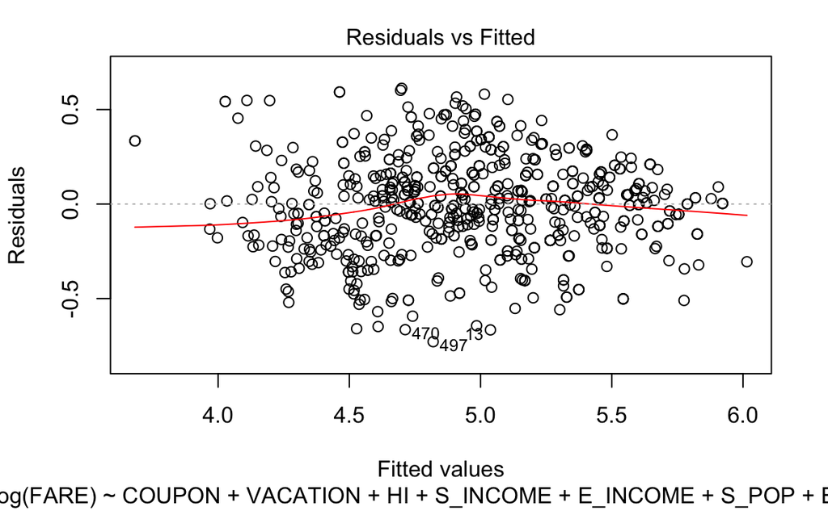

```r
mlr3 <- lm(log(FARE) ~ COUPON + VACATION + HI + S_INCOME + E_INCOME + S_POP + E_POP + DISTANCE + PAX + S_INCOME:S_POP + DISTANCE:COUPON + I(PAX^2), data=airfares)
plot(mlr3, which = 1)
```

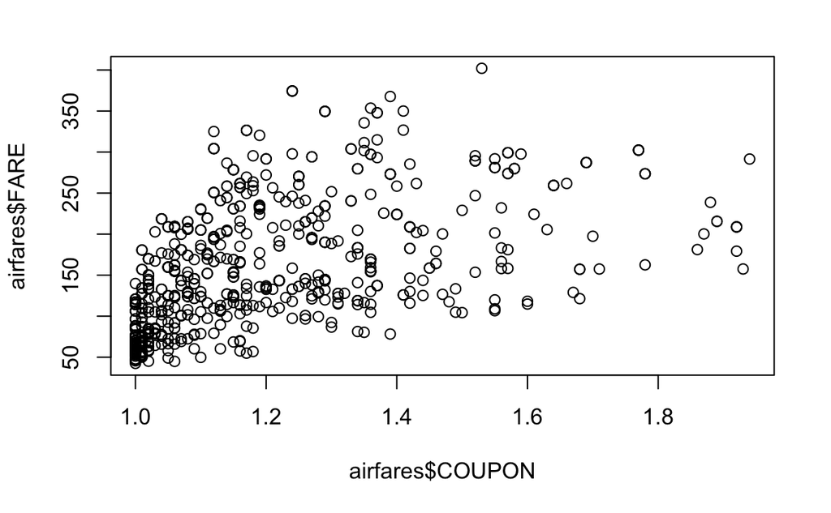

```r
plot(airfares$FARE ~ airfares$COUPON)
```

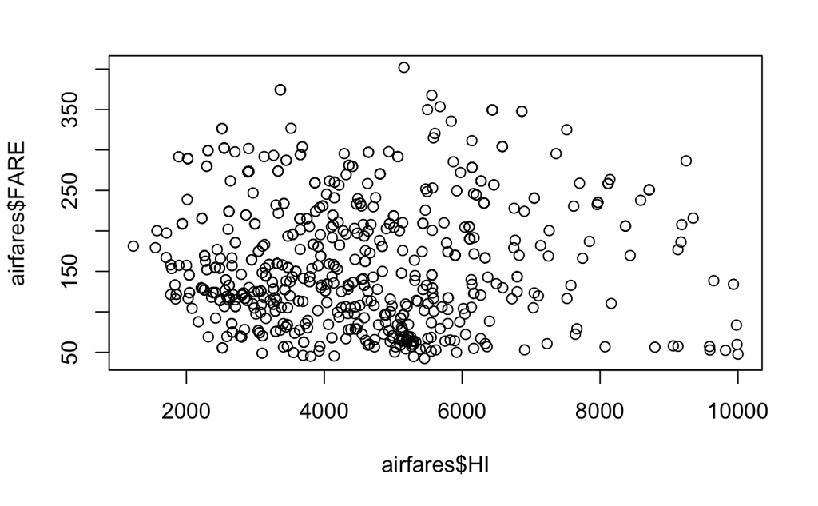

```r
plot(airfares$FARE ~ airfares$HI)
```

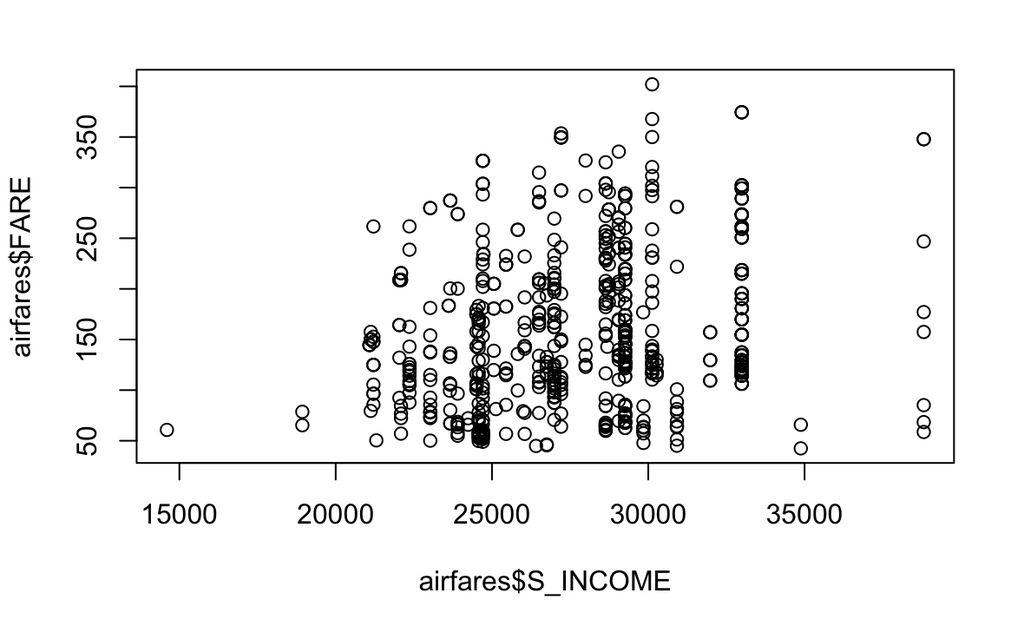

```r
plot(airfares$FARE ~ airfares$S_INCOME)
```

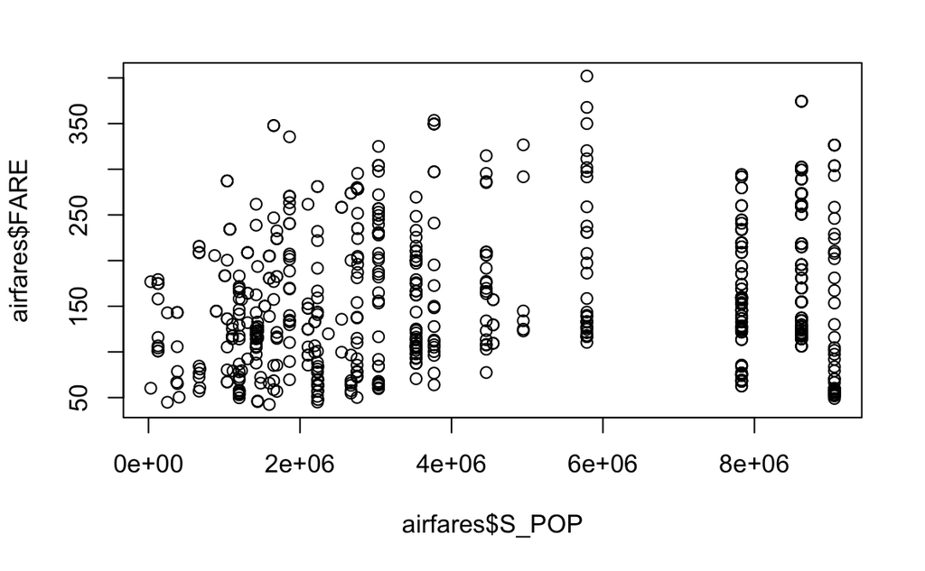

```r
plot(airfares$FARE ~ airfares$S_POP)
```

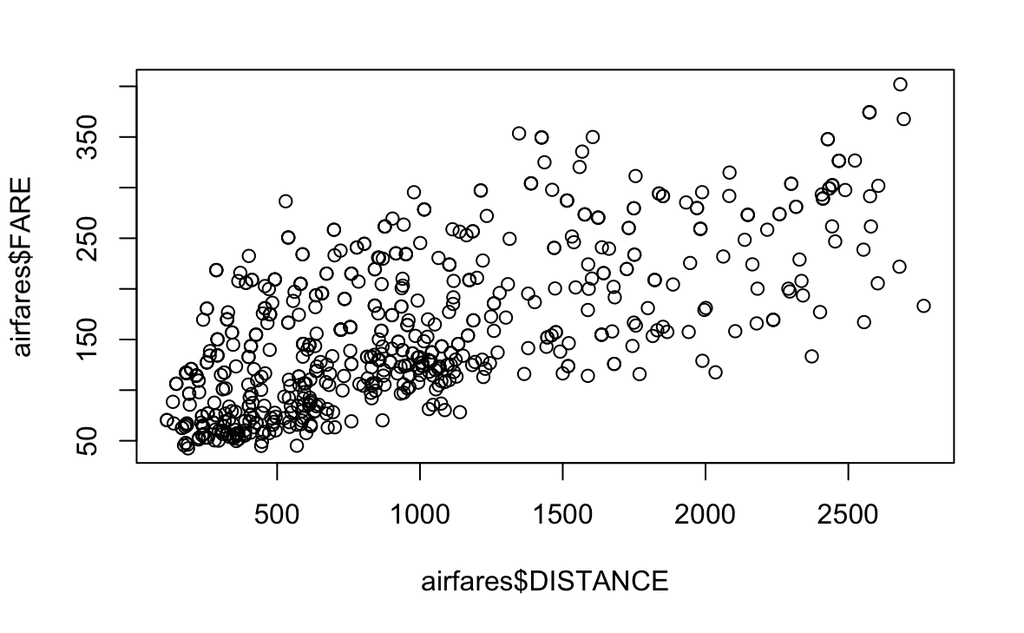

```r
plot(airfares$FARE ~ airfares$DISTANCE)
```

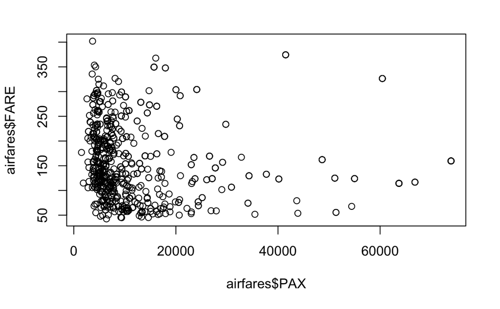

```r
plot(airfares$FARE ~ airfares$PAX)
```

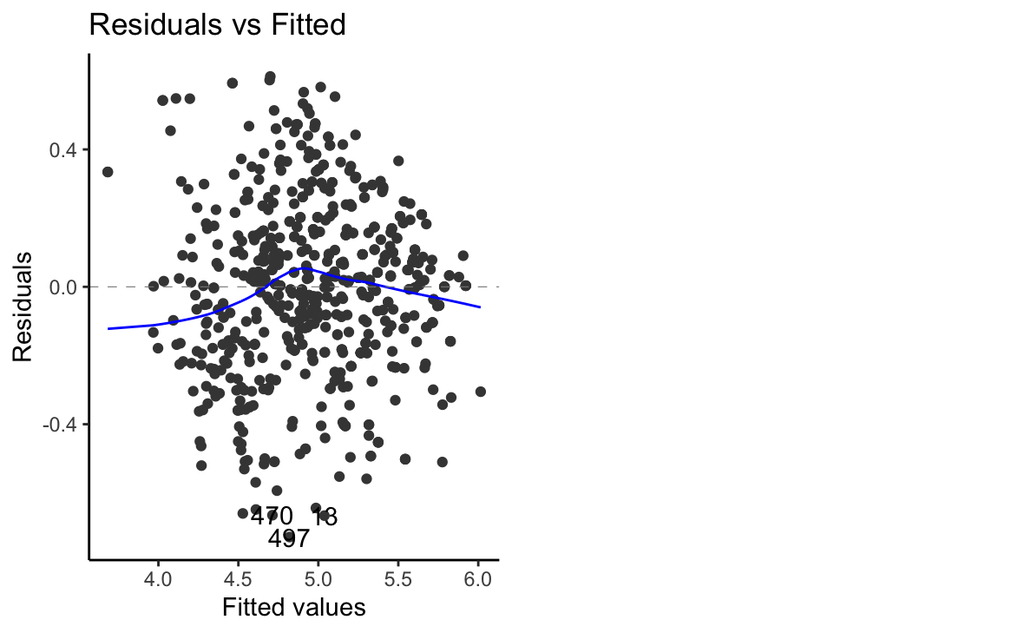

```r
autoplot(mlr3, which = 1) + theme_classic()
```

Added terms : $s.income*s.pop\\distance*coupon\\pax^2$

$fare_i=\beta_0+\beta_1coupon_i+\beta_2D_{vacation,i}+\beta_3HI_i+\beta_4s.income_i+\beta_5e.income_i+\beta_6s.pop_i\\+\beta_7e.pop_i+\beta_8distance_i+\beta_{9}pax_i+\beta_{10}(s.income_i*s.pop_i)\\+\beta_{11}(distance_i*coupon_i)+\beta_{12}pax_i^2+\varepsilon_i, \varepsilon_i\sim_{i.i.d}(0,\sigma^2)$

$H_0: \beta_{10}=\beta_{11}=\beta_{12}=0$

Comparing two models:

```r
mlr4 <- lm(FARE ~ COUPON + VACATION + HI + S_INCOME + E_INCOME + S_POP + E_POP + DISTANCE + PAX + S_INCOME:S_POP + DISTANCE:COUPON + I(PAX^2), data=airfares)
anova(mlr2, mlr4)
```

```
Analysis of Variance Table

Model 1: FARE ~ COUPON + VACATION + HI + S_INCOME + E_INCOME + S_POP +
    E_POP + DISTANCE + PAX
Model 2: FARE ~ COUPON + VACATION + HI + S_INCOME + E_INCOME + S_POP +
    E_POP + DISTANCE + PAX + S_INCOME:S_POP + DISTANCE:COUPON +
    I(PAX^2)
  Res.Df     RSS Df Sum of Sq      F    Pr(>F)
1    628 1038548
2    625  906948  3    131599 30.229 < 2.2e-16 ***
---
Signif. codes:  0 ‘***’ 0.001 ‘**’ 0.01 ‘*’ 0.05 ‘.’ 0.1 ‘ ’ 1
```

### Outliers

```r
par(mfrow=c(1,2))
plot(mlr3, which = 3)
plot(rstandard(mlr3))
```

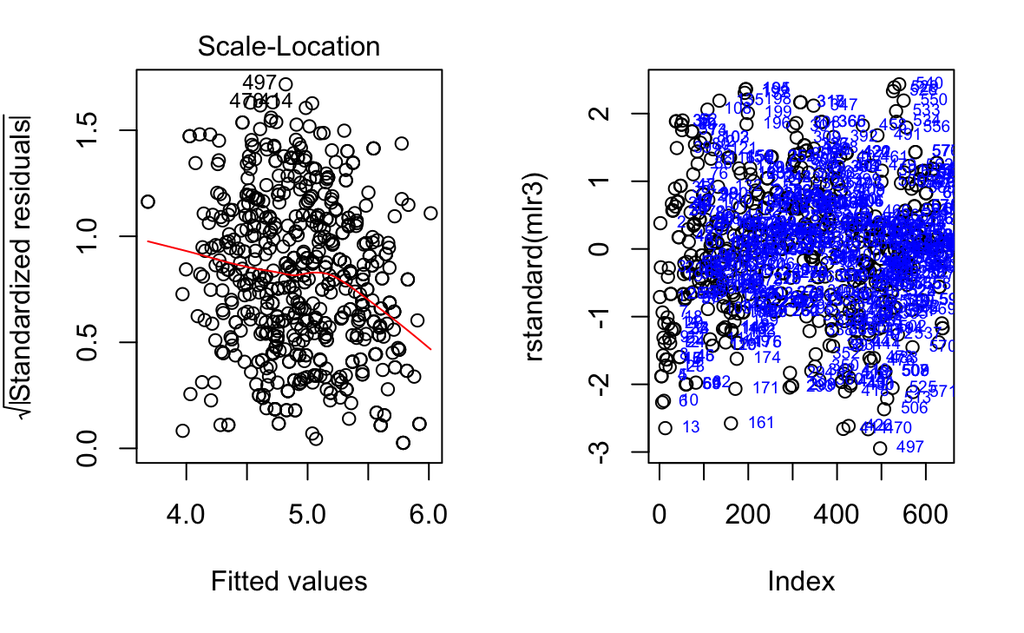

```r
text(x=1:nrow(airfares), y=rstandard(mlr3), rownames(airfares), cex = 0.6, pos=4, col = "blue")
```

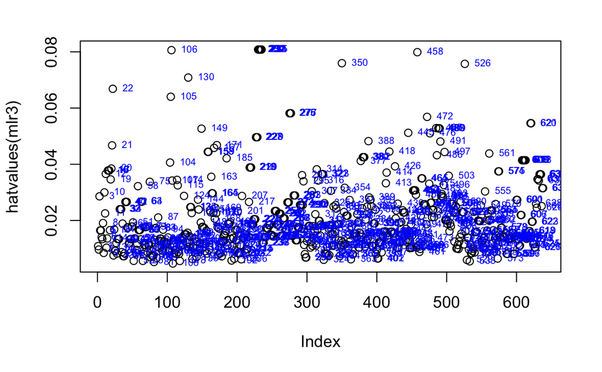

```r
# high leverage values
plot(hatvalues(mlr3))
text(x=1:nrow(airfares), y=hatvalues(mlr3), rownames(airfares), cex = 0.6, pos=4, col = "blue")
```

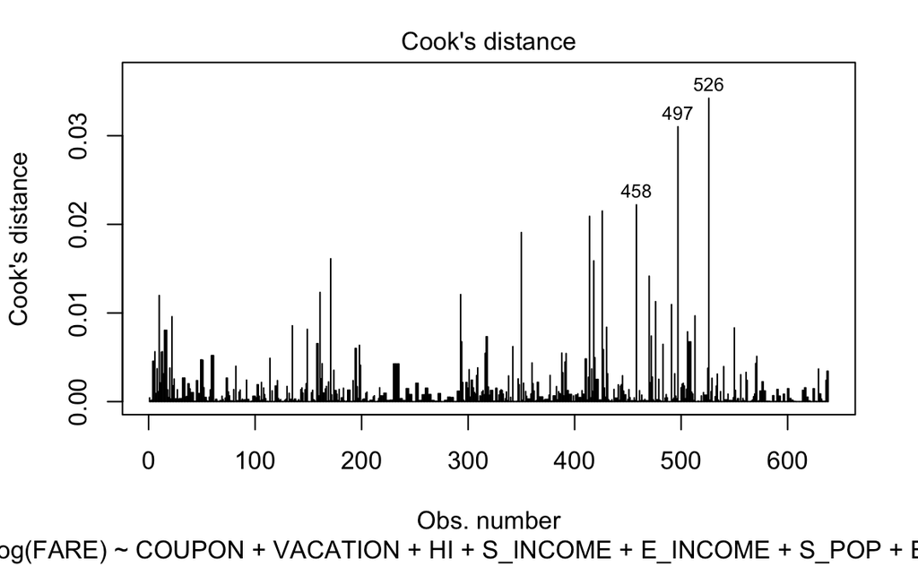

```r
# influential observations
plot(mlr3, which = 4)
```

```r
summary(mlr3)
```

```
Call:
lm(formula = log(FARE) ~ COUPON + VACATION + HI + S_INCOME +
    E_INCOME + S_POP + E_POP + DISTANCE + PAX + S_INCOME:S_POP +
    DISTANCE:COUPON + I(PAX^2), data = airfares)

Residuals:
     Min       1Q   Median       3Q      Max
-0.72850 -0.16617  0.00869  0.16236  0.61245

Coefficients:
                  Estimate Std. Error t value Pr(>|t|)
(Intercept)      2.599e+00  2.448e-01  10.616  < 2e-16 ***
COUPON           9.648e-01  1.530e-01   6.306 5.41e-10 ***
VACATIONYes     -1.650e-01  2.637e-02  -6.255 7.38e-10 ***
HI               5.819e-05  7.059e-06   8.244 9.86e-16 ***
S_INCOME         5.041e-07  5.491e-06   0.092    0.927
E_INCOME         1.403e-05  2.595e-06   5.408 9.09e-08 ***
S_POP           -1.605e-07  2.895e-08  -5.543 4.40e-08 ***
E_POP            6.256e-08  4.995e-09  12.526  < 2e-16 ***
DISTANCE         1.363e-03  1.024e-04  13.313  < 2e-16 ***
PAX             -2.556e-05  2.918e-06  -8.759  < 2e-16 ***
I(PAX^2)         2.805e-10  4.109e-11   6.826 2.06e-11 ***
S_INCOME:S_POP   7.050e-12  1.007e-12   7.002 6.52e-12 ***
COUPON:DISTANCE -7.164e-04  8.210e-05  -8.726  < 2e-16 ***
---
Signif. codes:  0 ‘***’ 0.001 ‘**’ 0.01 ‘*’ 0.05 ‘.’ 0.1 ‘ ’ 1

Residual standard error: 0.2529 on 625 degrees of freedom
Multiple R-squared:  0.749, Adjusted R-squared:  0.7442
F-statistic: 155.4 on 12 and 625 DF,  p-value: < 2.2e-16
```

```r
mlr3.no.outlier <- lm(log(FARE) ~ COUPON + VACATION + HI + S_INCOME + E_INCOME + S_POP + E_POP + DISTANCE + PAX + S_INCOME:S_POP + DISTANCE:COUPON + I(PAX^2), data=airfares, subset=-c(497, 526))
summary(mlr3.no.outlier)
```

```
Call:
lm(formula = log(FARE) ~ COUPON + VACATION + HI + S_INCOME +
    E_INCOME + S_POP + E_POP + DISTANCE + PAX + S_INCOME:S_POP +
    DISTANCE:COUPON + I(PAX^2), data = airfares, subset = -c(497,
    526))

Residuals:
     Min       1Q   Median       3Q      Max
-0.67255 -0.16292  0.01396  0.16198  0.61216

Coefficients:
                  Estimate Std. Error t value Pr(>|t|)
(Intercept)      2.523e+00  2.438e-01  10.350  < 2e-16 ***
COUPON           1.002e+00  1.529e-01   6.555 1.17e-10 ***
VACATIONYes     -1.676e-01  2.621e-02  -6.396 3.13e-10 ***
HI               6.028e-05  7.032e-06   8.572  < 2e-16 ***
S_INCOME         9.698e-07  5.440e-06   0.178    0.859
E_INCOME         1.439e-05  2.579e-06   5.577 3.65e-08 ***
S_POP           -1.528e-07  2.877e-08  -5.309 1.54e-07 ***
E_POP            6.270e-08  4.948e-09  12.671  < 2e-16 ***
DISTANCE         1.396e-03  1.041e-04  13.410  < 2e-16 ***
PAX             -2.561e-05  2.890e-06  -8.861  < 2e-16 ***
I(PAX^2)         2.801e-10  4.069e-11   6.882 1.44e-11 ***
S_INCOME:S_POP   6.834e-12  9.994e-13   6.838 1.92e-11 ***
COUPON:DISTANCE -7.462e-04  8.353e-05  -8.933  < 2e-16 ***
---
Signif. codes:  0 ‘***’ 0.001 ‘**’ 0.01 ‘*’ 0.05 ‘.’ 0.1 ‘ ’ 1

Residual standard error: 0.2505 on 623 degrees of freedom
Multiple R-squared:  0.753, Adjusted R-squared:  0.7483
F-statistic: 158.3 on 12 and 623 DF,  p-value: < 2.2e-16
```

```r
outliers <- airfares %>% select(FARE, S_CITY, E_CITY, COUPON, VACATION, S_INCOME, E_INCOME, DISTANCE, PAX)
outliers[c(497,526),]
```

| FARE | S_CITY | E_CITY | COUPON | VACATION | S_INCOME | E_INCOME | DISTANCE | PAX |
| --- | --- | --- | --- | --- | --- | --- | --- | --- |
| 59.80 | Burbank CA | San Jose CA | 1.00 | No | 24706 | 34880 | 296 | 10770 |
| 238.73 | Orlando FL | Seattle/Tacoma WA | 1.88 | Yes | 22360 | 30916 | 2553 | 3183 |

### Logistic Regression

$p_i=P(vacation_i=1 | fare_i, coupon_i,new_i,HI_i, s.income_i, e.income_i, s.pop_i, e.pop_i, distance_i, pax_i)$

then

$vacation_i \sim_{indep.}Bin(1,p_i)\\log(\frac{p_i}{1-p_i})=\beta_0+\beta_1fare_i+\beta_2coupon_i+\beta_3new_i+\beta_4HI_i+\beta_5s.income_i+\beta_6e.income_i+\beta_7s.pop_i+\beta_8e.pop_i+\beta_9distance_i+\beta_{10}pax_i$

```r
airfares1 <- airfares %>% mutate(VACATION=ifelse(VACATION=="Yes", 1, 0))
glm1 <- glm(VACATION ~ FARE +COUPON+ NEW+ HI+ S_INCOME+ E_INCOME+ S_POP+ E_POP+ DISTANCE+ PAX, family = binomial, data=airfares1)
summary(glm1)
```

```
Call:
glm(formula = VACATION ~ FARE + COUPON + NEW + HI + S_INCOME +
    E_INCOME + S_POP + E_POP + DISTANCE + PAX, family = binomial,
    data = airfares1)

Deviance Residuals:
    Min       1Q   Median       3Q      Max
-2.1289  -0.6641  -0.3094   0.5369   2.3866

Coefficients:
              Estimate Std. Error z value Pr(>|z|)
(Intercept)  4.033e+00  1.671e+00   2.414 0.015762 *
FARE        -2.269e-02  3.316e-03  -6.843 7.77e-12 ***
COUPON      -4.927e-01  8.965e-01  -0.550 0.582613
NEW         -1.423e-01  1.352e-01  -1.052 0.292575
HI          -1.298e-04  8.309e-05  -1.563 0.118153
S_INCOME    -8.761e-05  3.447e-05  -2.541 0.011040 *
E_INCOME     3.059e-05  2.582e-05   1.185 0.236137
S_POP       -1.757e-07  4.726e-08  -3.718 0.000201 ***
E_POP       -2.437e-07  6.122e-08  -3.981 6.87e-05 ***
DISTANCE     2.470e-03  3.813e-04   6.479 9.26e-11 ***
PAX          2.587e-05  1.190e-05   2.174 0.029718 *
---
Signif. codes:  0 ‘***’ 0.001 ‘**’ 0.01 ‘*’ 0.05 ‘.’ 0.1 ‘ ’ 1

(Dispersion parameter for binomial family taken to be 1)

    Null deviance: 739.7  on 637  degrees of freedom
Residual deviance: 532.5  on 627  degrees of freedom
AIC: 554.5

Number of Fisher Scoring iterations: 5
```

```r
# checking for model significance
glm.null <- glm(VACATION ~ 1, data=airfares1, family = "binomial")
anova(glm.null, glm1, test = "LRT")
```

```
Analysis of Deviance Table

Model 1: VACATION ~ 1
Model 2: VACATION ~ FARE + COUPON + NEW + HI + S_INCOME + E_INCOME + S_POP +
    E_POP + DISTANCE + PAX
  Resid. Df Resid. Dev Df Deviance  Pr(>Chi)
1       637      739.7
2       627      532.5 10    207.2 < 2.2e-16 ***
---
Signif. codes:  0 ‘***’ 0.001 ‘**’ 0.01 ‘*’ 0.05 ‘.’ 0.1 ‘ ’ 1
```

$H_0: \beta_1=\beta_2=\beta_3=\beta_4=\beta_5=\beta_6=\beta_7=\beta_8=\beta_9=\beta_{10}=0$

```r
vif(glm1)
```

```
    FARE   COUPON      NEW       HI S_INCOME E_INCOME    S_POP    E_POP
4.064510 3.290945 1.044400 1.561500 1.374036 1.346944 1.695168 1.882269
DISTANCE      PAX
5.033945 2.015265
```

```r
glm2 <- glm(VACATION ~ FARE +COUPON+ NEW+ HI+ S_INCOME+ E_INCOME+ S_POP+ E_POP+ PAX, family = binomial, data=airfares1)
vif(glm2)
```

```
    FARE   COUPON      NEW       HI S_INCOME E_INCOME    S_POP    E_POP
2.154776 2.442012 1.022271 1.539229 1.524963 1.429006 1.828251 2.085272
     PAX
2.130129
```

```r
# variable selection
step(glm2)
```

```
Start:  AIC=603.35
VACATION ~ FARE + COUPON + NEW + HI + S_INCOME + E_INCOME + S_POP +
    E_POP + PAX

           Df Deviance    AIC
- NEW       1   583.43 601.43
- E_INCOME  1   585.00 603.00
<none>          583.35 603.35
- S_INCOME  1   592.48 610.48
- HI        1   593.34 611.34
- PAX       1   595.47 613.47
- COUPON    1   595.50 613.50
- FARE      1   600.16 618.16
- S_POP     1   604.60 622.60
- E_POP     1   619.80 637.80

Step:  AIC=601.43
VACATION ~ FARE + COUPON + HI + S_INCOME + E_INCOME + S_POP +
    E_POP + PAX

           Df Deviance    AIC
- E_INCOME  1   585.03 601.03
<none>          583.43 601.43
- S_INCOME  1   592.69 608.69
- HI        1   593.51 609.51
- COUPON    1   595.54 611.54
- PAX       1   595.58 611.58
- FARE      1   600.31 616.31
- S_POP     1   604.62 620.62
- E_POP     1   619.96 635.96

Step:  AIC=601.03
VACATION ~ FARE + COUPON + HI + S_INCOME + S_POP + E_POP + PAX

           Df Deviance    AIC
<none>          585.03 601.03
- HI        1   594.41 608.41
- S_INCOME  1   595.08 609.08
- COUPON    1   596.83 610.83
- PAX       1   599.64 613.64
- FARE      1   600.31 614.31
- S_POP     1   607.53 621.53
- E_POP     1   620.00 634.00

Call:  glm(formula = VACATION ~ FARE + COUPON + HI + S_INCOME + S_POP +
    E_POP + PAX, family = binomial, data = airfares1)

Coefficients:
(Intercept)         FARE       COUPON           HI     S_INCOME        S_POP
  2.520e+00   -8.437e-03    2.494e+00   -2.361e-04   -1.077e-04   -2.146e-07
      E_POP          PAX
 -3.254e-07    4.105e-05

Degrees of Freedom: 637 Total (i.e. Null);  630 Residual
Null Deviance:      739.7
Residual Deviance: 585  AIC: 601
```

$log(\frac{p_i}{1-p_i})=\beta_0+\beta_1fare_i+\beta_2coupon_i+\beta_3HI_i+\beta_4s.income_i+\beta_5s.pop_i+\beta_6e.pop_i+\beta_7pax_i$

```r
# checking model significance for the new model
glm3 <- glm(VACATION ~ FARE +COUPON+ HI+ S_INCOME+ S_POP+ E_POP+ PAX, family = binomial, data=airfares1)
anova(glm.null, glm3, test = "LRT")
```

```
Analysis of Deviance Table

Model 1: VACATION ~ 1
Model 2: VACATION ~ FARE + COUPON + HI + S_INCOME + S_POP + E_POP + PAX
  Resid. Df Resid. Dev Df Deviance  Pr(>Chi)
1       637     739.70
2       630     585.03  7   154.67 < 2.2e-16 ***
---
Signif. codes:  0 ‘***’ 0.001 ‘**’ 0.01 ‘*’ 0.05 ‘.’ 0.1 ‘ ’ 1
```

```r
summary(glm3)
```

```
Call:
glm(formula = VACATION ~ FARE + COUPON + HI + S_INCOME + S_POP +
    E_POP + PAX, family = binomial, data = airfares1)

Deviance Residuals:
    Min       1Q   Median       3Q      Max
-1.7850  -0.7260  -0.4179   0.6182   2.3549

Coefficients:
              Estimate Std. Error z value Pr(>|z|)
(Intercept)  2.520e+00  1.434e+00   1.758 0.078787 .
FARE        -8.437e-03  2.277e-03  -3.705 0.000212 ***
COUPON       2.494e+00  7.341e-01   3.397 0.000681 ***
HI          -2.361e-04  8.035e-05  -2.938 0.003302 **
S_INCOME    -1.077e-04  3.448e-05  -3.123 0.001790 **
S_POP       -2.146e-07  4.691e-08  -4.575 4.76e-06 ***
E_POP       -3.254e-07  5.913e-08  -5.503 3.74e-08 ***
PAX          4.105e-05  1.057e-05   3.882 0.000104 ***
---
Signif. codes:  0 ‘***’ 0.001 ‘**’ 0.01 ‘*’ 0.05 ‘.’ 0.1 ‘ ’ 1

(Dispersion parameter for binomial family taken to be 1)

    Null deviance: 739.70  on 637  degrees of freedom
Residual deviance: 585.03  on 630  degrees of freedom
AIC: 601.03

Number of Fisher Scoring iterations: 5
```

```r
exp(glm3$coefficients)
```

```
(Intercept)        FARE      COUPON          HI    S_INCOME       S_POP
 12.4281572   0.9915988  12.1059370   0.9997640   0.9998923   0.9999998
      E_POP         PAX
  0.9999997   1.0000411
```

```r
exp(1000*4.105e-05)
```

```
[1] 1.041904
```

```r
exp(confint(glm3))
```

```
                2.5 %      97.5 %
(Intercept) 0.7652549 213.6297427
FARE        0.9870408   0.9959081
COUPON      2.9046710  51.9580320
HI          0.9996015   0.9999171
S_INCOME    0.9998236   0.9999591
S_POP       0.9999997   0.9999999
E_POP       0.9999996   0.9999998
PAX         1.0000202   1.0000619
```